# Assignment 2 for Statistical Computing and Empirical Mathods

Kexin Wu

10/6/2021

## 1 Visualisation

```r
library(tidyverse)
library(Stat2Data)
data("Hawks")
hawksSmall <- drop_na(select(Hawks, Age, Day, Month, Year, CaptureTime, Species, Wing, Weight, Tail))
```

# 1.1 Types of variables

Check how many rows and columns hawksSmall using the dim() function.

```r
dim(hawksSmall)
```

```
## [1] 897   9
```

Use the head() function to display the top 5 rows of the hawksSmall data frame.

```r
head(hawksSmall)
```

```
##   Age Day Month Year CaptureTime Species Wing Weight Tail
## 1   I  19     9 1992       13:30      RT  385    920  219
## 2   I  22     9 1992       10:30      RT  376    930  221
## 3   I  23     9 1992       12:45      RT  381    990  235
## 4   I  23     9 1992       10:50      CH  265    470  220
## 5   I  27     9 1992       11:15      SS  205    170  157
## 6   I  28     9 1992       11:25      RT  412   1090  230
```

# 1.2 What’s wrong with this plot?

# 1.3 Generate a histogram

Next use a combination of the functions ggplot() and geom_histogram to create a histogram plot of the weights of the Hawks within the hawksSmall data frame with bin widths of 100 grams.

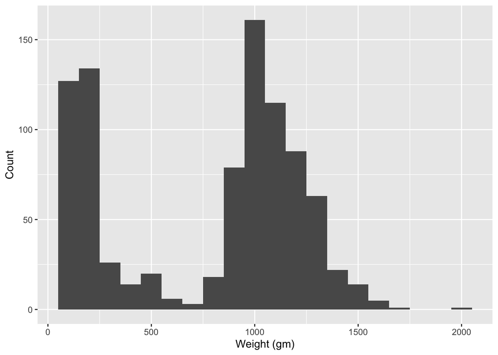

```r
ggplot(data = hawksSmall, aes(x = Weight)) + xlab("Weight (gm)") +
  geom_histogram(binwidth = 100) + ylab("Count")
```

Describe the aesthetic used within this plot: Weight

Which term best describes the shape of the data distribution of Hawk weights: “Unimodal”, “Bimodal” or “Trimodal”? Bimodal

# 1.4 Generate a density plot

Use a combination of the functions ggplot() and geom_density() to create a density plot of the tail lengths of the Hawks within the hawksSmall data frame.

Recreate your plot with the argument adjust = 0.5 and adjust = 1. Describe the role played by the adjust argument within the geom_density() function.

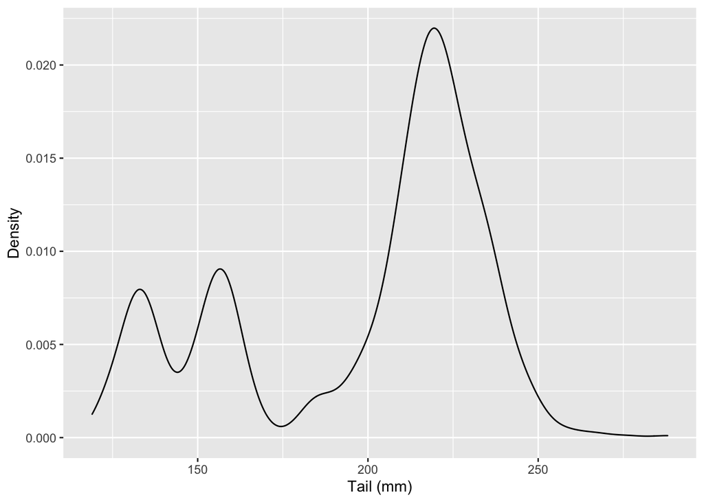

```r
ggplot(data = hawksSmall, aes(x = Tail)) + xlab("Tail (mm)") +
  geom_density(adjust = 0.5) + ylab("Density")
```

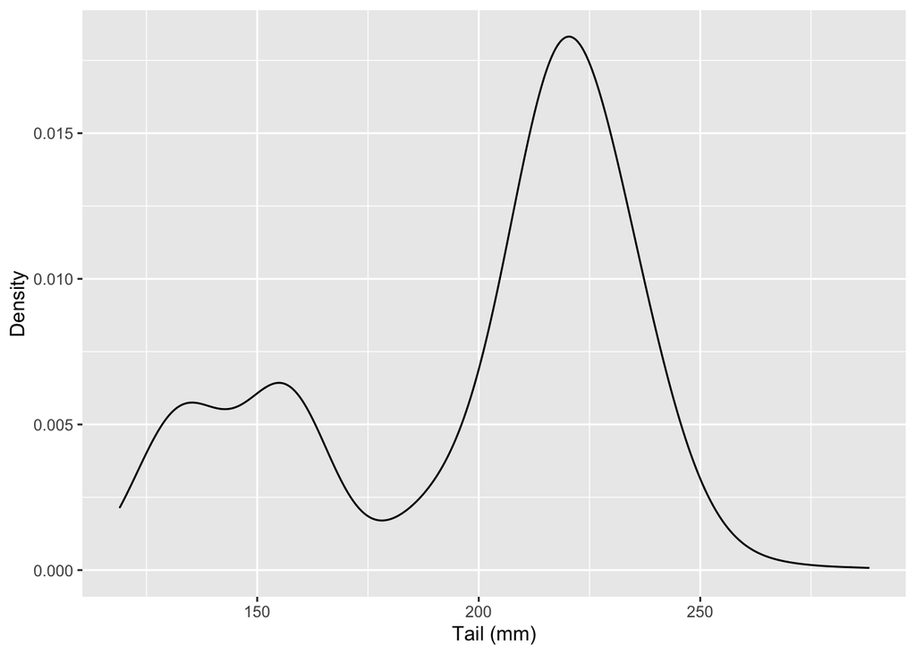

```r
ggplot(data = hawksSmall, aes(x = Tail)) + xlab("Tail (mm)") +
  geom_density(adjust = 1) + ylab("Density")
```

Create another density plots which including 3 species as 3 different colors

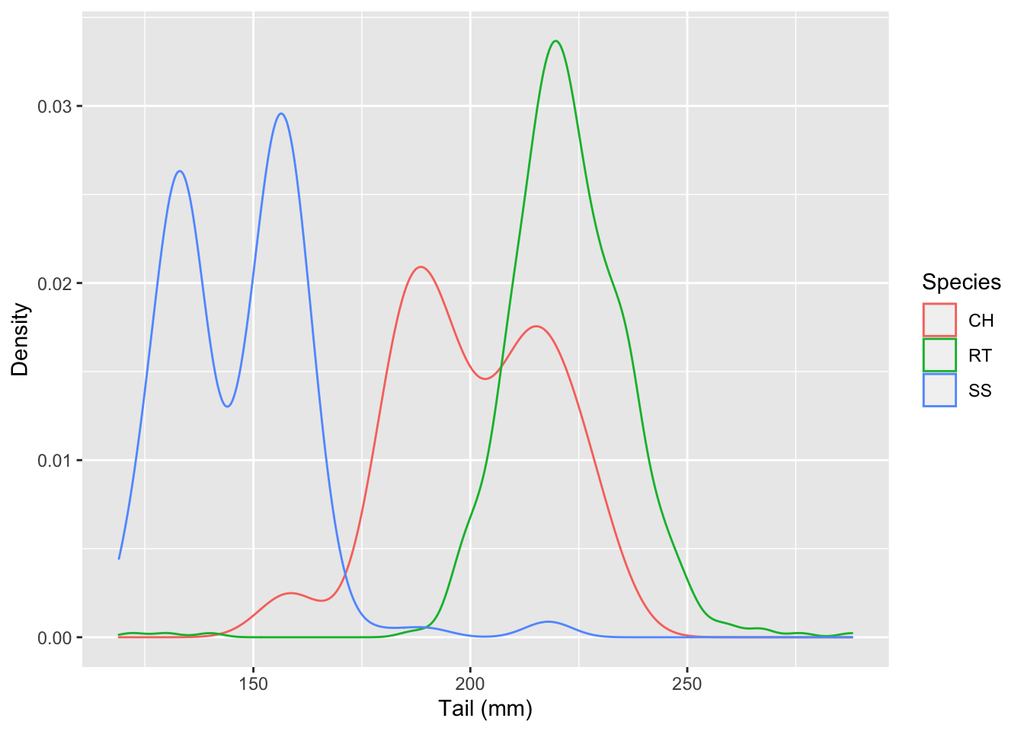

```r
ggplot(data = hawksSmall, aes(x = Tail, color = Species)) + xlab("Tail (mm)") +
  geom_density(adjust = 1) + ylab("Density")
```

Create a violin plots which including 3 species as 3 different colors

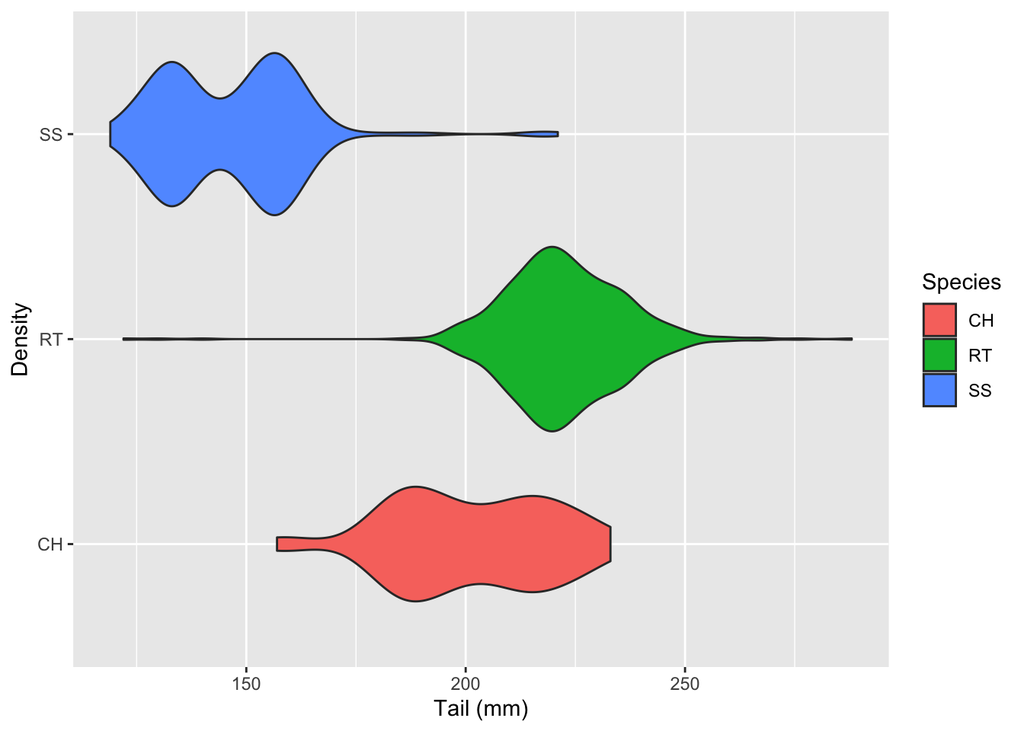

```r
ggplot(data = hawksSmall, aes(x = Tail, y = Species, fill = Species)) + xlab("Tail (mm)") +
  geom_violin(adjust = 1) + ylab("Density")
```

# 1.5 Scatter plots

Createa a scatter points using the ggplot() and geom_point() functions

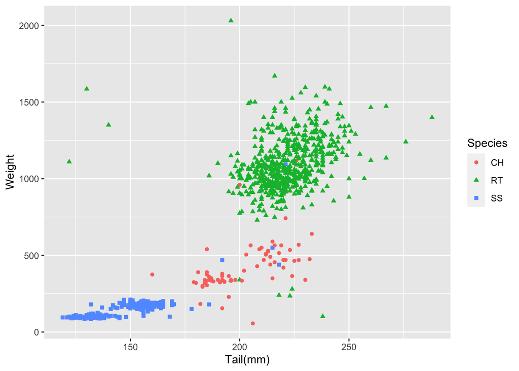

```r
ggplot(data = hawksSmall, aes(x = Tail, color = Species, shape = Species, y = Weight)) + xlab("Tail(mm)") + geom_point() + ylab("Weight")
```

# 1.6 Trend lines and facet wraps

Generate a plot using the ggplot(), geom_point(), geom_smooth() and facet_wrap() functions.

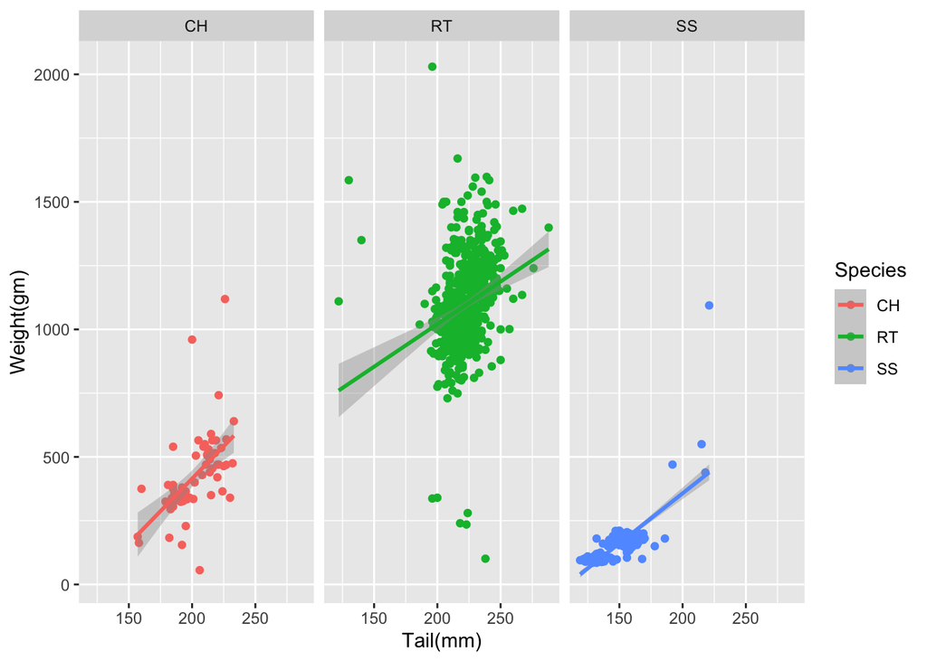

```r
ggplot(data = hawksSmall, aes(x = Tail, color = Species, y = Weight)) + xlab("Tail(mm)") +
  geom_point() + geom_smooth(method = 'lm') + facet_wrap(~Species) + ylab("Weight(gm)")
```

## 2 Data wrangling

# 2.1 Select and filter functions

Use a combination of the select() and filter() functions to generate a data frame called “hSF” which is a sub-table of the original Hawks data frame with the following characteristics:

1. Your data frame should include the columns:
   1. “Wing”,
   2. “Weight”
   3. “Tail”.
2. Your data frame should contain a row for every hawk such that:
   1. They belong to the species of Red-Tailed hawks
   2. They have weight at least 1kg.

Make use of the pipe operator to simplify your code.

```r
head(hawksSmall)
```

```
##   Age Day Month Year CaptureTime Species Wing Weight Tail
## 1   I  19     9 1992       13:30      RT  385    920  219
## 2   I  22     9 1992       10:30      RT  376    930  221
## 3   I  23     9 1992       12:45      RT  381    990  235
## 4   I  23     9 1992       10:50      CH  265    470  220
## 5   I  27     9 1992       11:15      SS  205    170  157
## 6   I  28     9 1992       11:25      RT  412   1090  230
```

```r
hSF <- select(filter(hawksSmall, Species == "RT" & Weight >= 1000), Wing, Weight, Tail)
head(hSF)
```

```
##   Wing Weight Tail
## 1  412   1090  230
## 2  412   1210  210
## 3  405   1120  238
## 4  393   1010  222
## 5  371   1010  217
## 6  390   1120  213
```

```r
head(
  hawksSmall %>%
    filter(Species == "RT" & Weight >= 1000) %>%
    select(Wing, Weight, Tail)
)
```

```
##   Wing Weight Tail
## 1  412   1090  230
## 2  412   1210  210
## 3  405   1120  238
## 4  393   1010  222
## 5  371   1010  217
## 6  390   1120  213
```

# 2.2 The arrange function

Use the arrange() function to sort the hSF data frame created in the previous section so that the rows appear in order of increasing wing span.

Use the head command to print out the top five rows of your sorted data frame.

```r
head(hSF %>%
       arrange(Wing)
)
```

```
##    Wing Weight Tail
## 1  37.2   1180  210
## 2 111.0   1340  226
## 3 199.0   1290  222
## 4 241.0   1320  235
## 5 262.0   1020  200
## 6 277.0   1500  207
```

# 2.3 Join and rename functions

The species of Hawks within the data frame have been indicated via a two letter code.

Recreate the data frame containing the correspondence between codes and the full species names and give your data frame an appropriate name.

```r
Species <- unique(hawksSmall$Species)
species_name_full <- c("Red-tailed", "Cooper's", "Sharp-shinned")
full_name <- arrange(data_frame(Species, species_name_full), Species)
full_name
```

```
## # A tibble: 3 × 2
##   Species species_name_full
##   <fct>   <chr>
## 1 CH      Cooper's
## 2 RT      Red-tailed
## 3 SS      Sharp-shinned
```

Use a combination of the functions left_join(), the rename() and the **select()* functions to create a new data frame called “hawksFullName” which is the same as the “Hawks” data frame except that the Species column contains the full names rather than the two letter codes.

```r
hawksFullName <- hawksSmall %>%
  left_join(full_name) %>%
  select(species_name_full, Wing, Weight) %>%
  rename(Species = species_name_full)
```

Use a combination of the head() and select() functions to print out the top seven rows of the columns “Species”, “Wing” and “Weight” of the data frame called “hawksFullName”.

```r
head(hawksFullName)
```

```
##         Species Wing Weight
## 1    Red-tailed  385    920
## 2    Red-tailed  376    930
## 3    Red-tailed  381    990
## 4      Cooper's  265    470
## 5 Sharp-shinned  205    170
## 6    Red-tailed  412   1090
```

# 2.4 The mutate function

Suppose that the fictitious “Healthy Hawks Society”1 has proposed a new measure called the “bird BMI” which attempts to measure mass of a hawk standardized by their wing span. The bird BMI is equal to the weight of the hawk (in grams) divided by their wing span (in millimeters) squared. That is,

Bird-BMI := 1000 × Weight/Wing-span^2.

Use the mutate(), select() and arange() functions to create a new data frame called “hawksWithBMI” which has the same number of rows as the original Hawks data frame but only two columns - one with their Species and one with their “bird BMI”. The rows should appear in descending order of “bird BMI”.

```r
hawksWithBMI <- hawksSmall %>%
  mutate(bird_BMI = 1000 * Weight / (Wing * Wing)) %>%
  select(Species, bird_BMI) %>%
  arrange(desc(bird_BMI))
head(hawksWithBMI)
```

```
##   Species  bird_BMI
## 1      RT 852.69973
## 2      RT 108.75741
## 3      RT  32.57493
## 4      RT  22.72688
## 5      CH  22.40818
## 6      RT  19.54932
```

```r
hawksWithBMI %>%
  filter(bird_BMI > 100)
```

```
##   Species bird_BMI
## 1      RT 852.6997
## 2      RT 108.7574
```

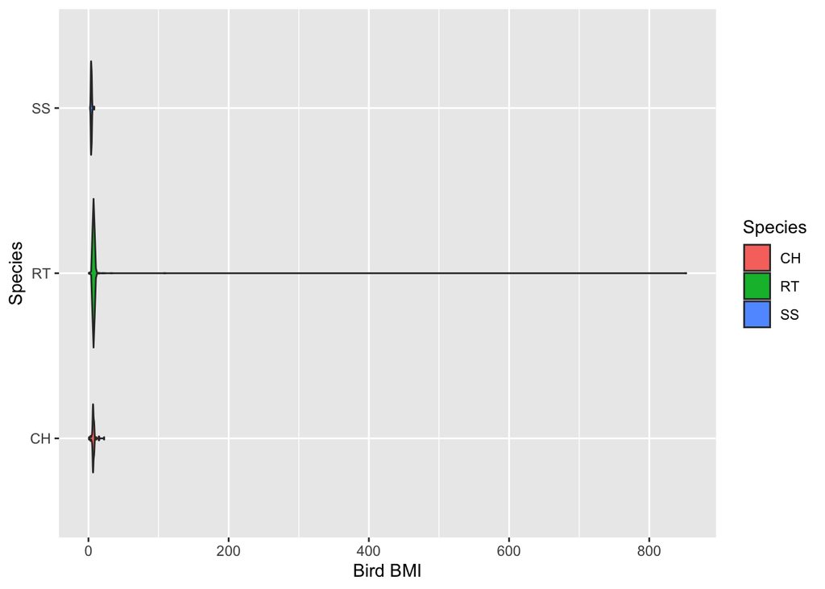

```r
ggplot(data = hawksWithBMI, aes(x = bird_BMI, y = Species, fill = Species)) + xlab("Bird BMI") +
  geom_violin(adjust = 1) + ylab("Species")
```

# 2.5 Summarize and group-by functions

Using the dataframe “hawksFullName”, from problem 3 above, in combination with the summarize() and the groupby functions, create a summary table, broken down by Hawk species, which contains the following summary quantities:

1. The number of rows;
2. The mean average wing span in centimeters;
3. The median wing span in centimeters;
4. The trimmed mean average wing span in centimeters (trim=0.1); 5. The mean average of the ratio between wing span and tail length.

```r
hawksFullName <- hawksSmall %>%
  left_join(full_name) %>%
  select(species_name_full, Wing, Tail) %>%
  rename(Species = species_name_full)
hawksFullName %>%
  group_by(Species) %>%
  summarize(
    num_rows = n(), mn_wing = mean(Wing, na.rm = TRUE), md_wing = median(Wing, na.rm = TRUE), t_mn_wing = median(Wing, na.rm = TRUE, trim = 0.1), tail_wing_ratio = mean(Wing / Tail, na.rm = TRUE)
  )
```

```
## # A tibble: 3 × 6
##   Species       num_rows mn_wing md_wing t_mn_wing tail_wing_ratio
##   <chr>            <int>   <dbl>   <dbl>     <dbl>           <dbl>
## 1 Cooper's            69    244.     240       240            1.22
## 2 Red-tailed         572    384.     384       384            1.73
## 3 Sharp-shinned      256    185.     191       191            1.26
```

Next create a summary table of the following form: Your summary table will show the number of missing values, broken down by species, for the columns Wing, Weight, Culmen, Hallux, Tail, StandardTail, Tarsus and Crop. You can complete this task by combining the select(), group_by(), summarize(), across(), everything(), sum() and is.na() functions.

```r
Hawks %>%
  left_join(full_name) %>%
  select(species_name_full, Wing, Weight, Culmen, Hallux, Tail, StandardTail, Tarsus, Crop) %>%
  rename(Species = species_name_full) %>%
  group_by(Species) %>%
  summarise(across(everything(), ~sum(is.na(.x))))
```

```
## # A tibble: 3 × 9
##   Species        Wing Weight Culmen Hallux  Tail StandardTail Tarsus  Crop
##   <chr>         <int>  <int>  <int>  <int> <int>        <int>  <int> <int>
## 1 Cooper's          1      0      0      0     0           19     62    21
## 2 Red-tailed        0      5      4      3     0          250    538   254
## 3 Sharp-shinned     0      5      3      3     0           68    233    68
```

## 3 Exploratory data analysis

We shall now illustrate some concepts from Lecture 5 on Exploratory Data Analysis in the context of our Hawks data set.

# 3.1 Combining location estimators with the summarise function

Use a combination of the summarise(), mean() and median() to compute the sample mean, sample median and trimmed sample mean (with q = 0.1) of the Hawk’s wing length and Hawk’s weight.

```r
Hawks %>%
  select(Wing, Weight) %>%
  summarise(Wing_mean = mean(Wing, na.rm = TRUE), Wing_t_mean = mean(Wing, trim = 0.1, na.rm = TRUE), Wing_med = median(Wing,  na.rm = TRUE), Weight = mean(Weight,  na.rm = TRUE), Weight_t_mean = mean(Weight, trim = 0.1,  na.rm = TRUE), Weight_med = median(Weight,  na.rm = TRUE))
```

```
##   Wing_mean Wing_t_mean Wing_med   Weight Weight_t_mean Weight_med
## 1  315.6375    322.2297      370 772.0802      772.0802   772.0802
```

Combine with the group_by() function to obtain a break down by species.

```r
Hawks %>%
  select(Species, Wing, Weight) %>%
  group_by(Species) %>%
  summarise(Wing_mean = mean(Wing, na.rm = TRUE), Wing_t_mean = mean(Wing, trim = 0.1, na.rm = TRUE), Wing_med = median(Wing,  na.rm = TRUE), Weight = mean(Weight,  na.rm = TRUE), Weight_t_mean = mean(Weight, trim = 0.1,  na.rm = TRUE), Weight_med = median(Weight,  na.rm = TRUE))
```

```
## # A tibble: 3 × 7
##   Species Wing_mean Wing_t_mean Wing_med Weight Weight_t_mean Weight_med
##   <fct>       <dbl>       <dbl>    <dbl>  <dbl>         <dbl>      <dbl>
## 1 CH           244.        243.      240   420.          420.       420.
## 2 RT           383.        385.      384  1094.         1094.      1094.
## 3 SS           185.        184.      191   148.          148.       148.
```

# 3.2 Location and dispersion estimatiors under linear transformations

Suppose further that X1, . . . , Xn has sample variance SX2 . What is the sample variance of X ̃1, . . . , X ̃n? What is the sample standard deviation of X ̃1, . . . , X ̃n?

# 3.3 Robustness of location estimators

In this exercise we shall investigate the robustness of several location estimators: The sample mean, sample median and trimmed mean.

We begin by extracting a vector called “hal” consisting of the talon lengths of all the hawks with any missing values removed.

```r
hal <- Hawks$Hallux
hal <- hal[!is.na(hal)]
```

To investigate the effect of outliers on estimates of location we generate a new vector called corrupted_hall” with 10 outliers each of value 100 created as follows:

```r
outlier_val <- 100
num_outliers <- 10
corrupted_hal <- c(hal, rep(outlier_val, times = num_outliers))
```

We can then compute the mean of the original sample and the corrupted sample as follows:

```r
mean(hal)
```

```
## [1] 26.41086
```

```r
mean(corrupted_hal)
```

```
## [1] 27.21776
```

Now let’s investigate what happens as the number of outliers changes from 0 to 1000. The code below generates a vector called “means_vect” which gives the sample means of corrupted samples with different numbers of outliers. More precisely, mean_vect is a vector of length 1001 with the i-th entry equal to the mean of a sample with i-1 outliers.

```r
num_outliers_vect <- seq(0, 1000)
means_vect <- c()

for (num_outliers in num_outliers_vect){
  corrupted_hal <- c(hal, rep(outlier_val, times = num_outliers))
  means_vect <- c(means_vect, mean(corrupted_hal))
}

head(means_vect)
```

```
## [1] 26.41086 26.49236 26.57367 26.65481 26.73576 26.81654
```

```r
tail(means_vect)
```

```
## [1] 65.00928 65.02771 65.04613 65.06453 65.08290 65.10126
```

Copy and modify the above code to create an additional vector caleed “medians_vect” of length 1001 with the i-th entry equal to the median of a sample “corrupted_hal” with i-1 outliers.

```r
num_outliers_vect <- seq(0, 1000)
medians_vect <- c()

for (num_outliers in num_outliers_vect) {
  corrupted_hal <- c(hal, rep(outlier_val, times = num_outliers))
  medians_vect <- c(medians_vect, median(corrupted_hal))
}

head(medians_vect)
```

```
## [1] 29.40 29.40 29.40 29.40 29.45 29.50
```

```r
tail(medians_vect)
```

```
## [1] 100 100 100 100 100 100
```

Ammend the code further to add an additional vector called “t_means_vect” of length 1001 with the i-th entry equal to the trimmed mean of a sample with i-1 outliers, where the trimmed mean has a trim funtion q = 0.1.

```r
num_outliers_vect <- seq(0, 1000)
t_means_vect <- c()

for (num_outliers in num_outliers_vect) {
  corrupted_hal <- c(hal, rep(outlier_val, times = num_outliers))
  t_means_vect <- c(t_means_vect, mean(corrupted_hal, trim = 0.1))
}

head(t_means_vect)
```

```
## [1] 25.88386 25.89371 25.90352 25.91345 25.92335 25.93322
```

```r
tail(t_means_vect)
```

```
## [1] 66.82992 66.85174 66.87354 66.90786 66.92962 66.95135
```

You should now have four vectors: “num_outliers_vect”, “means_vect”, “medians_vect” and “t_means_vect”. Combine these vectors into a data frame with the following code.

```r
df_means_medians <- data.frame(num_outliers = num_outliers_vect,
                               mean = means_vect, t_mean = t_means_vect,
                               median = medians_vect)
head(df_means_medians)
```

```
##   num_outliers     mean   t_mean median
## 1            0 26.41086 25.88386  29.40
## 2            1 26.49236 25.89371  29.40
## 3            2 26.57367 25.90352  29.40
## 4            3 26.65481 25.91345  29.40
## 5            4 26.73576 25.92335  29.45
## 6            5 26.81654 25.93322  29.50
```

```r
tail(df_means_medians)
```

```
##      num_outliers     mean   t_mean median
## 996           995 65.00928 66.82992    100
## 997           996 65.02771 66.85174    100
## 998           997 65.04613 66.87354    100
## 999           998 65.06453 66.90786    100
## 1000          999 65.08290 66.92962    100
## 1001         1000 65.10126 66.95135    100
```

Now use the code below to reshape and plot the data. The function pivot_longer() below is used to reshape the data. Don’t worry if this operation is unclear at this stage. Its use will be explained soon.

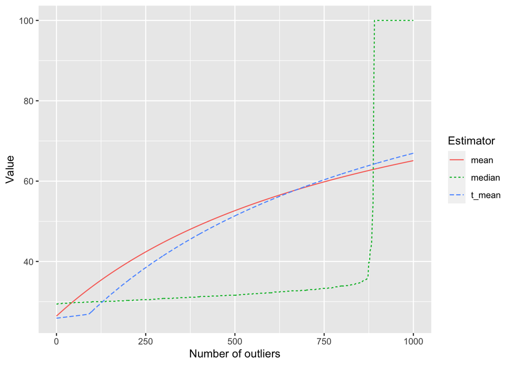

```r
df_means_medians %>%
  pivot_longer(!num_outliers, names_to = "Estimator", values_to = "Value") %>%
  ggplot(aes(x = num_outliers, color = Estimator, linetype = Estimator, y = Value)) +
  geom_line() + xlab("Number of outliers")
```

# 3.4 Box plots and outliiers

Use the function ggplot() and geom_boxplot() to create a box plot which summarises the distribution of hawk weights broken down by species.

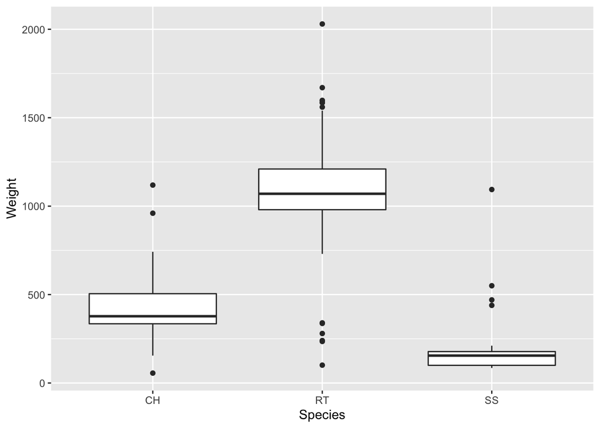

```r
ggplot(data = Hawks, aes(y = Weight, x = Species)) + geom_boxplot()
```

Note the outliers displayed as individual dots.

Suppose we have a sample X1, · · · , Xn. Let q25 denote the 0.25-quantile of the sample and let q75 denote the 0.75-quantile of the sample. We can then define the interquartile range, denoted IQR by IQR := q75 − q25. In the context of boxplots and outlier Xi is any numerical value such that the following holds if either of the following holds:

```
 Xi < q25 − 1.5 × IQR
 Xi > q75 + 1.5 × IQR.
```

Create a function called “num_outliers” which computes the number of outliers within a sample (with missing values excluded).

```r
outliers <- function(x){
  q25 <- quantile(x, 0.25, na.rm=1)
  q75 <- quantile(x, 0.75, na.rm=1)
  iq_range <- q75 - q25
  return(x[((x > q75 + 1.5 * iq_range) | (x < q25 - 1.5 * iq_range)) & !is.na(x)])
}
num_outliers <- function(x){
  return(length(outliers(x)))
}
```

Now combine your function num_outliers() with the functions group_by() and summarise() to compute the number of outlier for the three samples of hawk weights broken down by specied.

```r
Hawks %>%
  group_by(Species)%>%
  summarise(num_outliers_weight = num_outliers(Weight))
```

```
## # A tibble: 3 × 2
##   Species num_outliers_weight
##   <fct>                 <int>
## 1 CH                        3
## 2 RT                       13
## 3 SS                        4
```